*Draft! Prepared 2021-09-21 using country-reported data CSV files dated 2021-09-13 and estimates files dated 2021-08-16.*

### Fig. 3.3.1 Estimated TB treatment coverage (new and relapse patients as a percentage of estimated TB incidence) in 2020, 30 high TB burden countries, WHO regions and globally

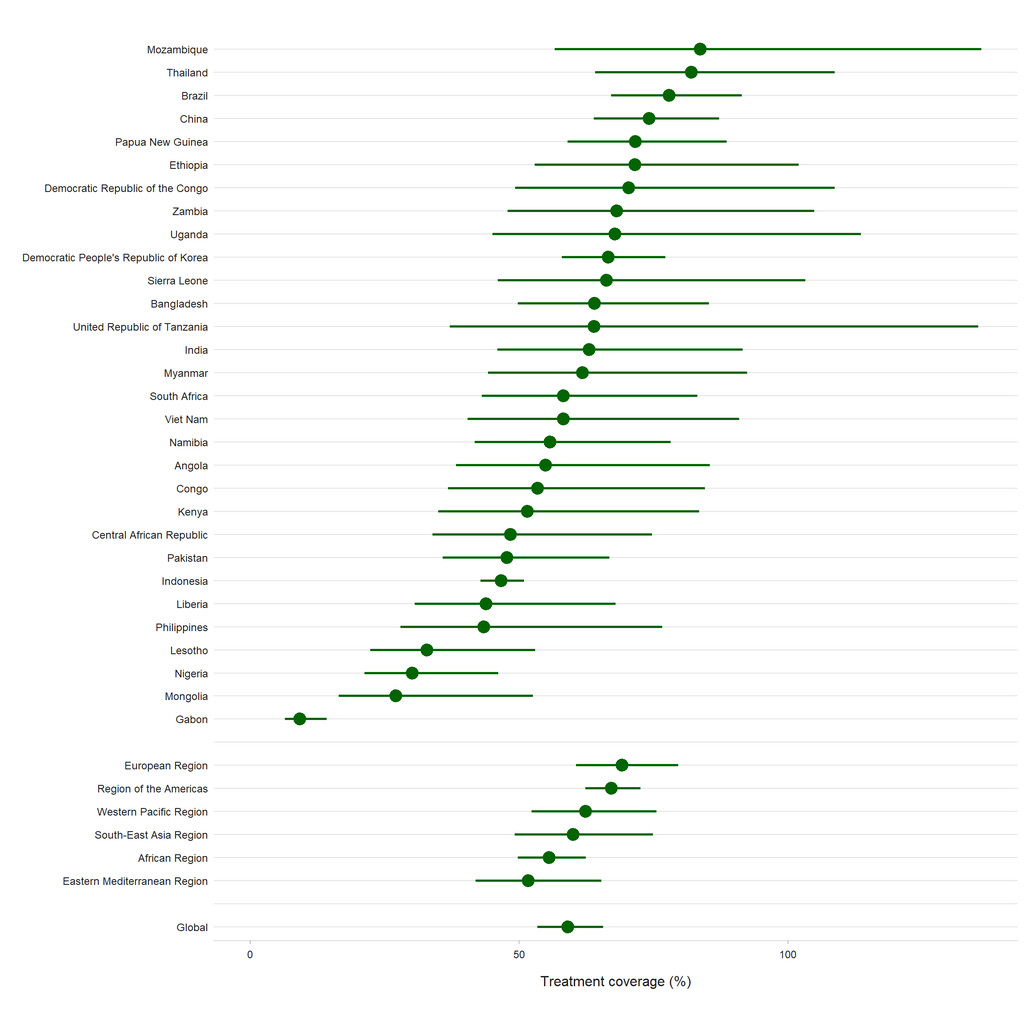

### Fig. 3.3.2 The ten countries with the largest gaps between notifications of new and relapse (incident) TB cases and the best estimates of TB incidence, 2020<sup>a</sup>

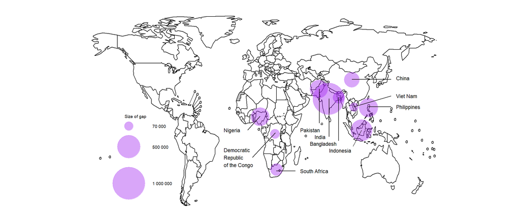

<sup>a</sup> The ten countries ranked in order of the size of the gap between notified cases and the best estimates of TB incidence in 2020 are: India, Indonesia, the Philippines, Nigeria, Pakistan, China, South Africa, Bangladesh, the Democratic Republic of the Congo and Viet Nam.

### Fig. 3.3.3 Estimated global number of incident HIV positive TB cases (red) compared with the global number of notified new and relapse TB cases known to be HIV-positive (black) and the global number of TB patients started on antiretroviral therapy (blue), 2004-2020

Shaded area represents uncertainty intervals

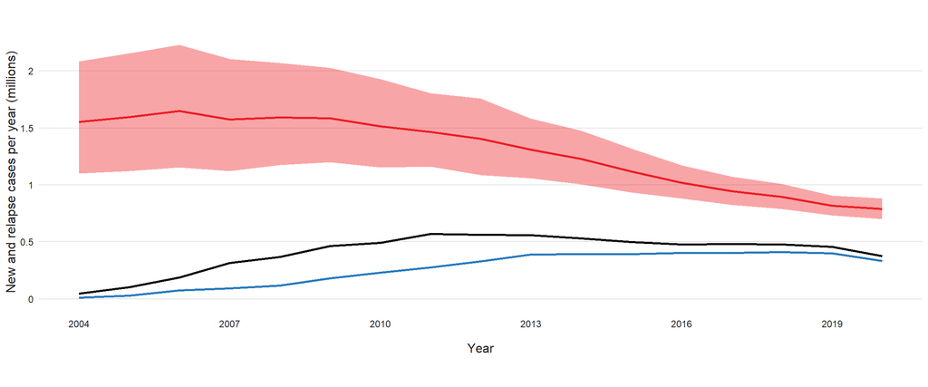

### Fig. 3.3.4 Estimated coverage of antiretroviral therapy for HIV-positive TB cases (HIV-positive TB patients on antiretroviral therapy as a percentage of the estimated incidence of HIV-positive TB) in 2020, 30 high TB/HIV burden countries, WHO regions and globally

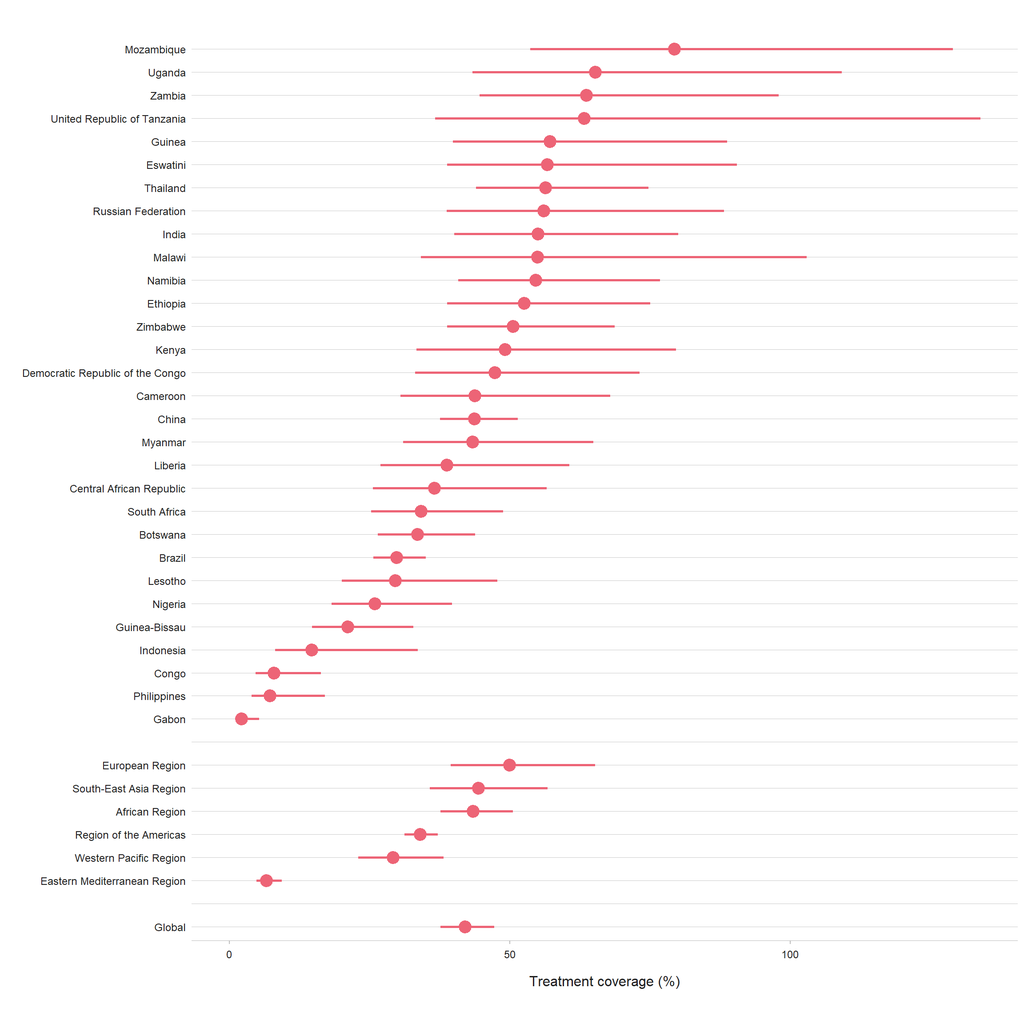

### Fig. 3.3.5 Treatment outcomes for new and relapse TB cases in 2019, WHO regions and globally

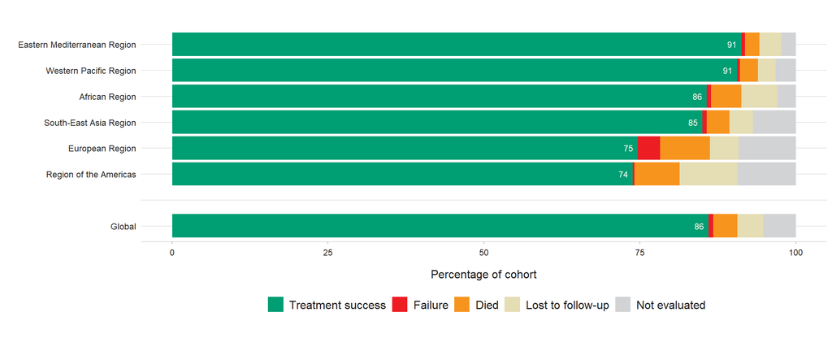

### Fig. 3.3.6 Treatment outcomes for new and relapse TB cases globally 2012-2019

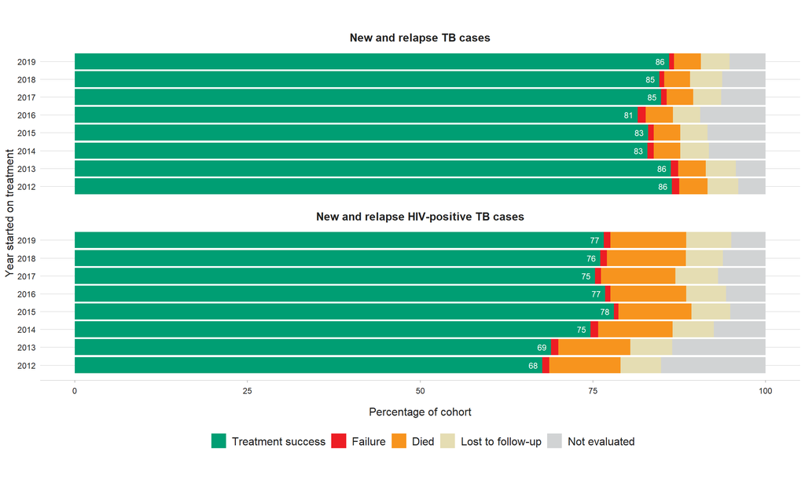

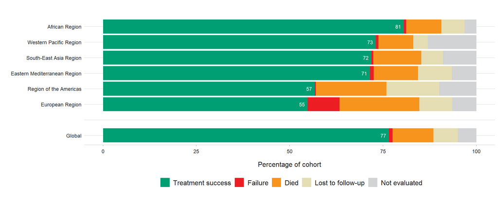

### Fig. 3.3.8 Treatment success rate for new and relapse TB cases in children aged 0-14 years in 2019, WHO regions and globally<sup>a</sup>

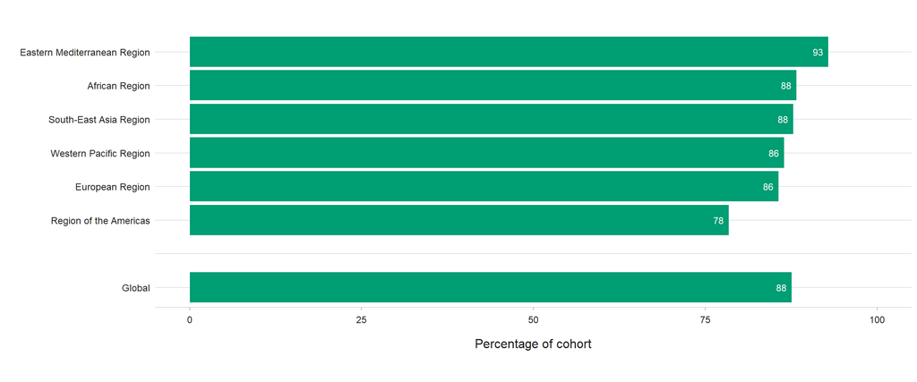

<sup>a</sup> Data reported by 143 countries on outcomes for 412 418 children aged 0-14 years, equivalent to 79% of the 523 820 cases among children aged 0-14 years that were notified in 2019.

### Fig. 3.3.9 Treatment outcomes for new and relapse TB cases (absolute numbers), 2000-2019, globally and for WHO regions

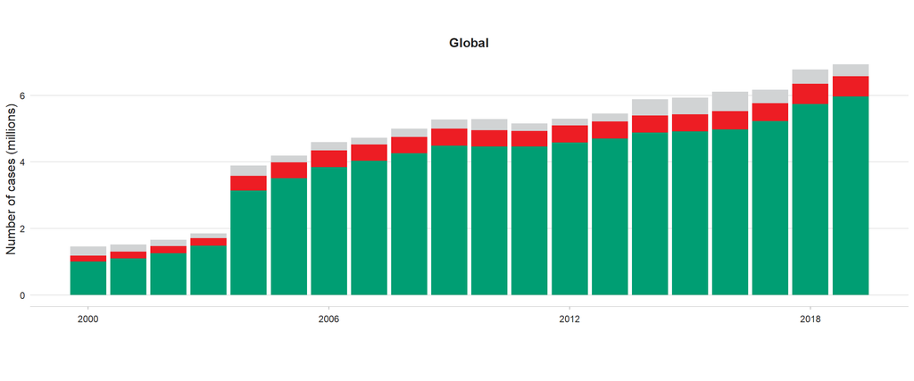

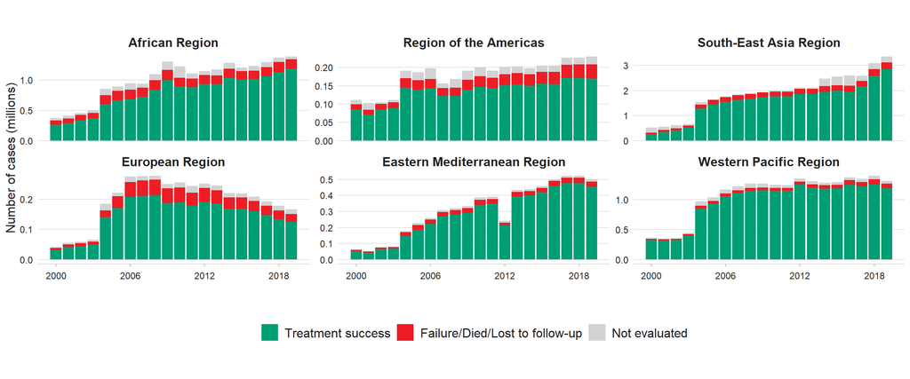

<sup>a</sup> Cohorts before 2012 included new cases only.

### Table 3.3.1 Cumulative number of deaths averted by TB and TB/HIV interventions 2000-2020 (in millions), globally and by WHO region

| WHO region | HIV-negative people Best estimate | HIV-negative people Uncertainty interval | HIV-positive people Best estimate | HIV-positive people Uncertainty interval | Total Best estimate | Total Uncertainty interval |
| --- | --- | --- | --- | --- | --- | --- |
| African Region | 6.6 | 5.5-7.7 | 8.2 | 6.9-9.45 | 15 | 13-17 |
| Region of the Americas | 1.8 | 1.7-2.0 | 0.34 | 0.31-0.38 | 2.2 | 2.0-2.3 |
| South-East Asia Region | 23 | 19-28 | 2.8 | 1.9-3.8 | 26 | 22-31 |
| European Region | 2.1 | 1.8-2.3 | 0.30 | 0.26-0.34 | 2.4 | 2.1-2.6 |
| Eastern Mediterranean Region | 4.7 | 4.1-5.3 | 0.083 | 0.065-0.10 | 4.8 | 4.2-5.4 |
| Western Pacific Region | 15 | 14-16 | 0.48 | 0.40-0.57 | 16 | 14-17 |
| Global | 54 | 47-60 | 12 | 11-14 | 66 | 59-73 |